# Final Project - STEM 680

Jerri Berry Danso

2025-05-13

## Introduction

This analysis uses the IPEDS dataset to explore metrics for UTK and its peer and aspirant institutions from 2018 to 2022. The goal is to explore two distinct research questions, accompanied by visualizations, to analyze trends and relationships in the data.

The dataset for this analysis was sourced from the National Center for Education Statistics (NCES) through the Integrated Postsecondary Education Data System (IPEDS). It includes data for the University of Tennessee, Knoxville (UTK) and a set of 10 peer and 6 aspirant institutions. A peer institution is a college or university selected for comparison based on similar characteristics such as size, mission, academic offerings, or student demographics. An aspirant institution is a college or university identified as a model or benchmark for future growth and improvement, often excelling in areas where the institution seeks to improve. Both sets of institutions were preselected by UTK leadership for benchmarking purposes. The dataset spans from Fall 2018 to Fall 2022 and includes variables such as endowment per Full-Time Equivalent (FTE) enrollment and 6-year graduation rates. IPEDS data is collected annually as part of NCES’s requirement for institutions that participate in federal student financial aid programs to report key metrics. This publicly available data provides a comprehensive look into institutional resources and outcomes, enabling a meaningful comparison of UTK’s performance relative to its peers and aspirants.

## Research Question 1

How do 6‑year graduation rates for men and women at UTK compare to those of its peer and aspirant institutions between 2018 and 2022?

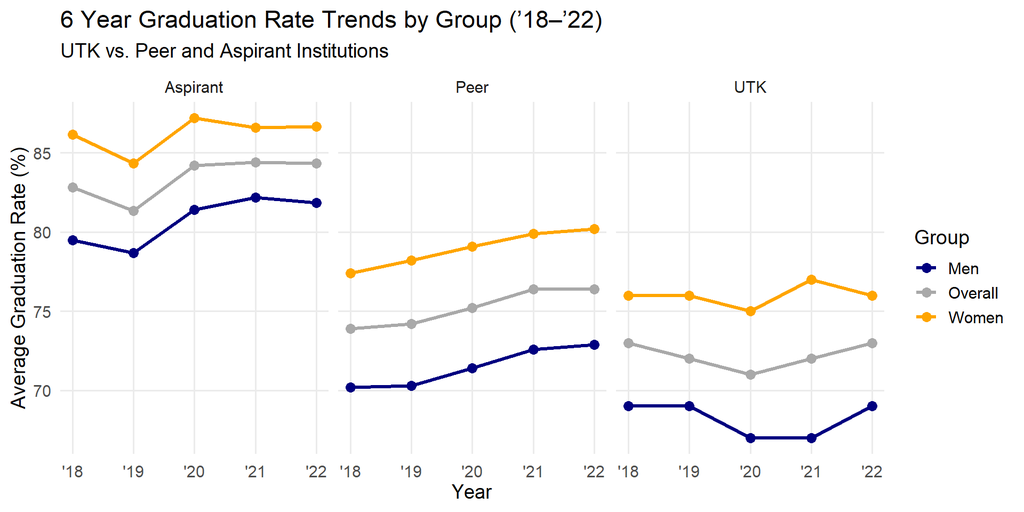

```r
# Load packages
library(tidyverse)
library(ggplot2)

# Read in CSV
data <- read_csv("IPEDS_data.csv")

# Recode UTK as its own group
RQ1 <- data %>%
  mutate(
    category = case_when(
      institution_name == "University of Tennessee, Knoxville" ~ "UTK",
      TRUE ~ institution_category
    )
  )

# Filter to relevant years and categories
data_sub <- RQ1 %>%
  filter(Year >= 2018, Year <= 2022, category %in% c("UTK", "Peer", "Aspirant"))


# Pivot longer so we have one row per (institution, year, gender)
grad_long <- data_sub %>%
  select(institution_name, category, Year,
         grad_rate_men, grad_rate_women, grad_rate_total) %>%
  pivot_longer(
    cols = starts_with("grad_rate_"),
    names_to    = "group",
    names_prefix= "grad_rate_",
    values_to   = "rate"
  ) %>%
  mutate(
    group = recode(group,
      men   = "Men",
      women = "Women",
      total = "Overall"
    )
  )

# Summarize to get the mean rate per category × year × group
avg_trends <- grad_long %>%
  group_by(category, Year, group) %>%
  summarize(
    mean_rate = mean(rate, na.rm = TRUE),
    .groups = "drop"
  ) %>%
  mutate(YearLabel = paste0("'", substr(Year, 3, 4)))


# Plot
p <- ggplot(avg_trends, aes(x = Year, y = mean_rate, color = group, group = group)) +
  geom_line(size = 1.2) +
  geom_point(size = 3) +
  facet_wrap(~ category) +
  scale_x_continuous(
    breaks = 2018:2022,
    labels = c("'18","'19","'20","'21","'22")
  ) +
  scale_color_manual(
    values = c(
      "Men"     = "navyblue",
      "Overall" = "darkgray",
      "Women"   = "orange"
    )
  ) +
  labs(
    title    = "6 Year Graduation Rate Trends by Group (’18–’22)",
    subtitle = "UTK vs. Peer and Aspirant Institutions",
    x        = "Year",
    y        = "Average Graduation Rate (%)",
    color    = "Group"
  ) +
  theme_minimal(base_size = 14) +
  theme(
    axis.text.x     = element_text(vjust = 0.5),
    panel.grid.minor= element_blank()
  )

print(p)
```

```r
# Define the folder (commented for knitting)
# output_folder <- "C:/Users/Babyc/OneDrive/3. ESM PhD Program/2. Spring 2025/STEM 680_Foundations of Ed Data Science/Final Project"

# Save RQ1 Faceted Line Graph (commented for knitting)
# ggsave(
# filename = file.path(output_folder, "RQ1.png"),
#   plot = last_plot(),
#  width = 10,
#  height = 5,
#  dpi = 300
#  )
```

Between 2018 and 2022, UTK’s six‑year graduation rates for men, women, and overall cohorts consistently trailed those of its peer and aspirant institutions by roughly 2–4 points versus peers and 10–13 points versus aspirants. Although UTK’s gender gap (women outpacing men by about eight points) mirrors peer norms, it spiked to ten points in 2021 before narrowing again. Notably, UTK men saw a two‑point decline during the pandemic years while UTK women remained comparatively resilient. This divergence suggests that targeted support for male students could help UTK close both its overall and gender‑specific completion gaps.

## Research Question 2

Is there a relationship between institutional endowment per FTE and 6‑year graduation rates for Black students across UTK, its peer, and aspirant institutions between 2018 and 2022?

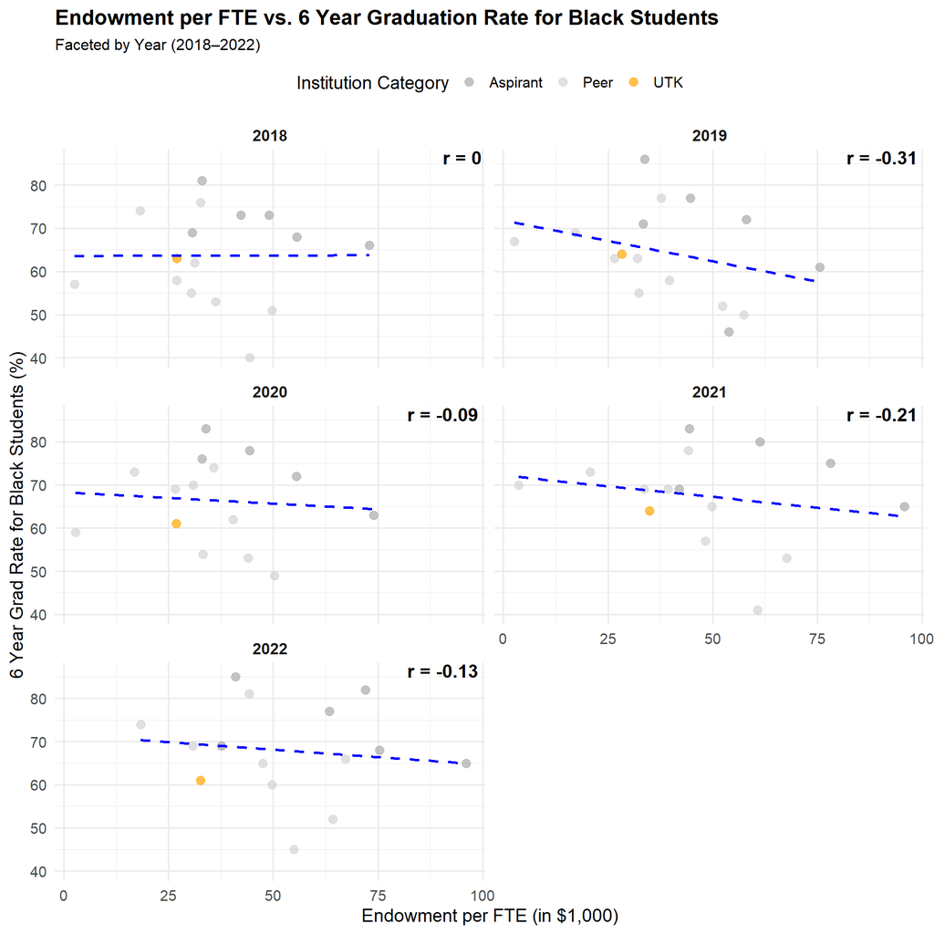

```r
# Load packages
library(tidyverse)
library(ggrepel)

# Wrangle for RQ2
RQ2 <- data %>%
  filter(Year >= 2018, Year <= 2022) %>%
  filter(!is.na(FTE_endow_GASB), !is.na(grad_rate_black)) %>%
  select(institution_name, institution_category, Year,
         FTE_endow_GASB, grad_rate_black)

# Compute per‐year correlations
cor_df <- RQ2 %>%
  group_by(Year) %>%
  summarize(corr_black = cor(FTE_endow_GASB, grad_rate_black), .groups = "drop")

# Merge back for annotation
RQ2 <- RQ2 %>%
  left_join(cor_df, by = "Year")

# Define custom colors
custom_colors <- c(
  "UTK"      = "orange",
  "Peer"     = "lightgray",
  "Aspirant" = "darkgray"
)

# Plot faceted scatter with regression and correlations
p2 <- ggplot(RQ2,
       aes(x = FTE_endow_GASB/1000, y = grad_rate_black,
           color = institution_category)) +
  geom_point(size = 3, alpha = 0.7) +
  geom_smooth(method = "lm", se = FALSE,
              linetype = "dashed", color = "blue") +
  # Label only UTK
  geom_text_repel(
    data = filter(RQ2, institution_name == "University of Tennessee, Knoxville"),
    aes(label = "UTK"),
    color = "orange", fontface = "bold"
  ) +
  scale_color_manual(values = custom_colors) +
  facet_wrap(~ Year, ncol = 2) +
  # Annotate each facet with its r‐value
  geom_text(
    data = cor_df,
    aes(x = Inf, y = Inf,
        label = paste0("r = ", round(corr_black, 2))),
    hjust = 1.1, vjust = 1.1,
    inherit.aes = FALSE,
    size = 5, fontface = "bold"
  ) +
  labs(
    title    = "Endowment per FTE vs. 6 Year Graduation Rate for Black Students",
    subtitle = "Faceted by Year (2018–2022)",
    x        = "Endowment per FTE (in $1,000)",
    y        = "6 Year Grad Rate for Black Students (%)",
    color    = "Institution Category"
  ) +
  theme_minimal(base_size = 14) +
  theme(
    legend.position  = "top",
    strip.text       = element_text(face = "bold", size = 12),
    plot.title       = element_text(face = "bold", size = 16),
    plot.subtitle    = element_text(size = 12)
  )

print(p2)
```

```r
# Define the folder (commented for knitting)
# output_folder <- "C:/Users/Babyc/OneDrive/3. ESM PhD Program/2. Spring 2025/STEM 680_Foundations of Ed Data Science/Final Project"

# Save RQ2 Scatterplot (commented for knitting)
# ggsave(
#  filename = "RQ2.png",
#  plot     = p2,
#  path     = output_folder,
#  width    = 10,
#  height   = 10,
#  dpi      = 300
#)
```